# Data Science II

Session 5: Rasters — Continuous Surfaces and Zonal Statistics

Bogdan G. Popescu

bgpopescu@tec.mx

Tec de Monterrey

## What You’ll Learn Today

1. What a **raster** is — and why it holds the same information as a table, stored differently
2. Reading, inspecting, and mapping rasters with **`terra`** and **`tidyterra`**
3. **Raster algebra** — arithmetic, masks, and changing the resolution
4. **`crop`**, **`mask`** and **`extract`** — turning a surface into a column in your table

Today’s data: **monthly temperature** across Mexico, and the GADM state boundaries.

## Before We Start

```r
#Step1: Libraries for today
library(terra)         # the modern raster package
library(sf)            # vectors, as before
library(dplyr)
library(ggplot2)
library(tidyterra)     # geom_spatraster, for ggplot
library(exactextractr) # area-weighted zonal statistics

sf_use_s2(FALSE)
```

Two small GeoTIFFs for `../data/raster/`, plus the GADM state boundaries you already know from Session 1:

- [rasters and `gadm41_MEX_1.shp` (Dropbox folder)](https://www.dropbox.com/scl/fo/2qdprbf3ewutxuv9w9q3y/ANHzn9jalz5y4LSC5NnvXQw?rlkey=fxyyas3o3w9nk4dbvy2jymco0&dl=0)

# Part A: What a Raster Is

## Vector and Raster

- Spatial data comes as a **vector** or a **raster**
- A river as a vector (left) and as a raster (right)

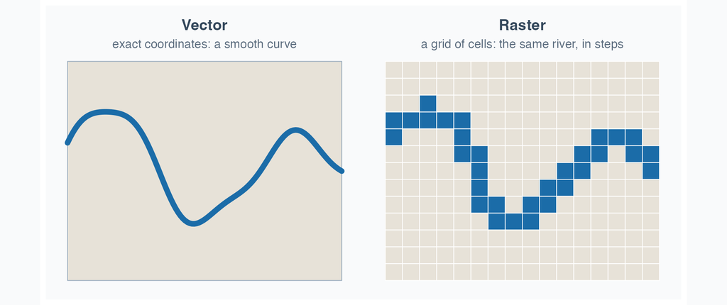

Sessions 1–4 were all **vectors**. Today is the other half.

## A Raster Is a Matrix with a Location

Strip away the jargon and a raster is **three things**:

1. A **matrix of numbers** — the cell values
2. An **extent** — the bounding box those cells cover
3. A **CRS** — what those coordinates mean

From extent and matrix dimensions you get **resolution**: how much ground one cell covers.

**Note**

A raster has no “features” and no attribute table. There is nothing to join to by name — only by **location**.

## Raster File Formats

| Format | Extension | Notes |
| --- | --- | --- |
| **GeoTIFF** | `.tif` | the default; universally readable |
| Cloud-Optimised GeoTIFF | `.tif` | a GeoTIFF you can read *partially*, over HTTP |
| NetCDF | `.nc` | many dimensions — climate time series |
| ASCII grid | `.asc` | plain text, huge, avoid |

Use **GeoTIFF** unless something forces you not to.

## Which R Package?

| Package | Status |
| --- | --- |
| `raster` | the old standard — **retired**, still everywhere online |
| **`terra`** | its replacement, by the same author. **Use this.** |
| `stars` | for data cubes: many dimensions, time series |
| `exactextractr` | one job, done fast: zonal statistics |

**Warning**

Just like `sp` in Session 3, most raster answers you find online are written for `raster`. `terra` uses `rast()` where `raster` used `raster()`, and objects are `SpatRaster`, not `RasterLayer`.

## Today’s Data: WorldClim

**WorldClim 2.1** — global climate surfaces interpolated from weather stations, free, at several resolutions.

- `mexico_tavg_monthly.tif` — mean temperature, **12 layers**, one per month
- `mexico_elevation.tif` — metres above sea level

Already cropped to Mexico. The global download is 37 MB; cropped, the two come to **300 KB**.

https://worldclim.org

# Part B: Reading and Inspecting

## Reading a Raster

```r
#Step1: rast() reads any raster format terra understands
tavg <- rast("../data/raster/mexico_tavg_monthly.tif")
tavg
```

```
class       : SpatRaster
size        : 112, 192, 12  (nrow, ncol, nlyr)
resolution  : 0.1666667, 0.1666667  (x, y)
extent      : -118.5, -86.5, 14.33333, 33  (xmin, xmax, ymin, ymax)
coord. ref. : lon/lat WGS 84 (EPSG:4326)
source      : mexico_tavg_monthly.tif
names       :       Jan,       Feb,       Mar,       Apr,       May,       Jun, ...
min values  :     3.154,   4.25175,   5.23275,   7.44325,    9.8045,   9.08475, ...
max values  : 27.126429, 27.564501, 29.026001, 31.155251, 32.101749, 31.525249, ...
```

## What That Told You

- **size** `112, 192, 12` — rows, columns, and **12 layers**
- **resolution** `0.1667` degrees — about 18 km at this latitude
- **extent** — the bounding box, in CRS units
- **coord. ref.** — EPSG:4326, as usual
- **names** — `Jan` through `Dec`; a layer is like a column

**Tip**

`print()` on a `SpatRaster` does not print the data — it prints the *description*. With 21,504 cells per layer that is a mercy.

## The Same Raster, as a Table

```r
#Step1: any raster can become a data frame -- x, y, one column per layer
tavg_df <- as.data.frame(tavg, xy = TRUE)

dim(tavg_df)
```

```
[1] 6789   14
```

```r
head(tavg_df[, 1:5], 3)
```

```
            x     y      Jan      Feb      Mar
211 -115.4167 32.75 12.50225 14.92875 17.32875
212 -115.2500 32.75 12.55275 15.18300 17.78650
213 -115.0833 32.75 13.02050 15.62750 18.26500
```

One **row per cell**, one **column per layer**. The 21,504 cells become 6,789 rows because `as.data.frame` drops the `NA` sea cells by default.

```r
#Step2: underneath, one layer is just a matrix -- no x, no y anywhere
as.matrix(tavg[["Jan"]], wide = TRUE)[1:3, 17:21]
```

```
        [,1]     [,2]     [,3]     [,4]     [,5]
[1,]     NaN      NaN      NaN      NaN      NaN
[2,]     NaN      NaN 12.50225 12.55275 13.02050
[3,] 13.6095 13.44675 13.37775 12.88275 12.77125
```

The same three January values, but **nothing in there says where they are**. Row 2, columns 19–21 *is* the location — extent and resolution turn an index into a coordinate.

## As RStudio Sees Them

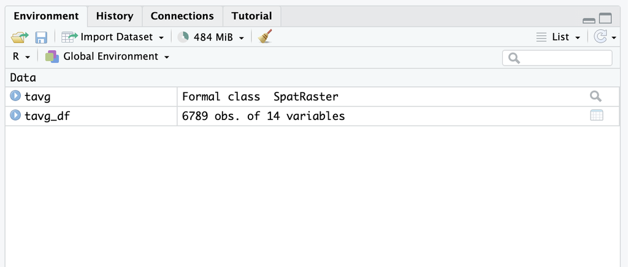

Same data, two objects. RStudio offers you `tavg_df` as a spreadsheet — **6,789 obs. of 14 variables**. For `tavg` it can only say **Formal class SpatRaster**, because there is no table in there to show you.

## Same Picture, Either Way

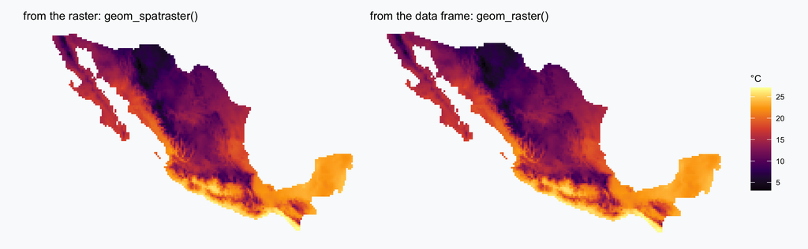

```r
#Step1: from the raster
ggplot() + geom_spatraster(data = tavg[["Jan"]])

#Step2: from the data frame -- ordinary ggplot2, nothing spatial about it
ggplot(tavg_df, aes(x = x, y = y, fill = Jan)) + geom_raster() + coord_equal()
```

The same map twice. `geom_raster()` is plain **ggplot2** — `x`, `y`, `fill`. Nothing in the right-hand panel knows it is a map.

## So Why Have Rasters at All?

The same 6,789 locations, stored three ways:

|  | what it stores | size |
| --- | --- | --- |
| `sf` points | a geometry **per cell** | 3,536 KB |
| data frame | `x` and `y` **columns** | 771 KB |
| `SpatRaster` | **no coordinates at all** | extent + resolution |

A raster’s cells are on a **regular grid**, so terra derives any cell’s coordinates from the extent and the resolution. Nothing positional is stored per cell — only the values.

**Note**

That is the whole trade. Vectors store **where each thing is**, because things sit anywhere. Rasters store **only values**, because the grid already says where. Everything else about rasters follows from this.

## Properties, One at a Time

```r
dim(tavg)          # rows, columns, layers
```

```
[1] 112 192  12
```

```r
res(tavg)          # cell size, in CRS units
```

```
[1] 0.1666667 0.1666667
```

```r
nlyr(tavg)         # how many layers
```

```
[1] 12
```

```r
names(tavg)[1:4]
```

```
[1] "Jan" "Feb" "Mar" "Apr"
```

```r
ext(tavg)
```

```
SpatExtent : -118.5, -86.5, 14.333333333333334, 33 (xmin, xmax, ymin, ymax)
```

## Getting at the Values

```r
#Step1: One layer behaves like a matrix
summary(values(tavg[["Jan"]]))
```

```
      Jan
 Min.   : 3.154
 1st Qu.:11.342
 Median :14.200
 Mean   :15.044
 3rd Qu.:18.929
 Max.   :27.126
 NAs    :14715
```

`NA` cells are the sea — we masked everything outside Mexico when the file was made. **Most raster cells in a real analysis are `NA`**, and every function needs `na.rm = TRUE`.

## Most of a Raster Is Nothing

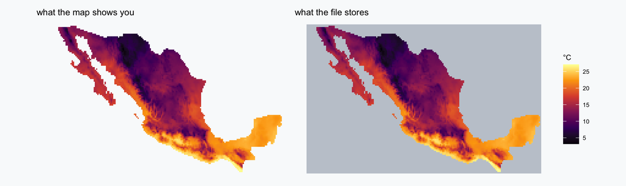

A raster is always a **rectangle**. 21,504 cells, of which 6,789 carry a value — **68% of this file is `NA`**. Mexico is just the part that happens to have data in it.

```r
mean(values(tavg[["Jan"]]))
```

```
[1] NaN
```

```r
mean(values(tavg[["Jan"]]), na.rm = TRUE)
```

```
[1] 15.04444
```

## Mapping: Base `plot`

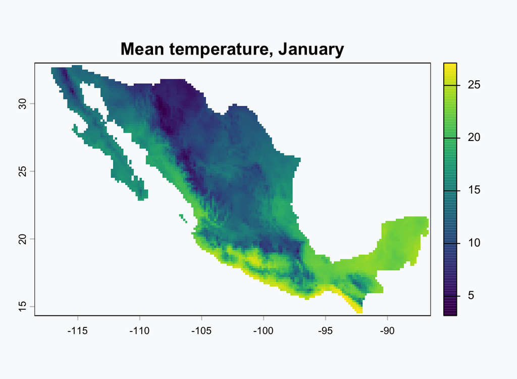

```r
plot(tavg[["Jan"]],
     main = "Mean temperature, January")
```

`terra`’s `plot` is fast and needs no arguments. Use it constantly while you work.

## Your Turn: Map July

We mapped January. **Map July instead — then put the two months side by side. Which part of the country changes most?**

```r
#Step1: pull one layer out by name -- or by position, tavg[[7]]
jul <- tavg[["Jul"]]

#Step2: map it exactly as before
plot(jul, main = "Mean temperature, July")

#Step3: now both months at once
plot(tavg[[c("Jan", "Jul")]], main = c("January", "July"))
```

Look hard at the **legends** on that last plot before you conclude anything.

## Mapping: `ggplot` + `tidyterra`

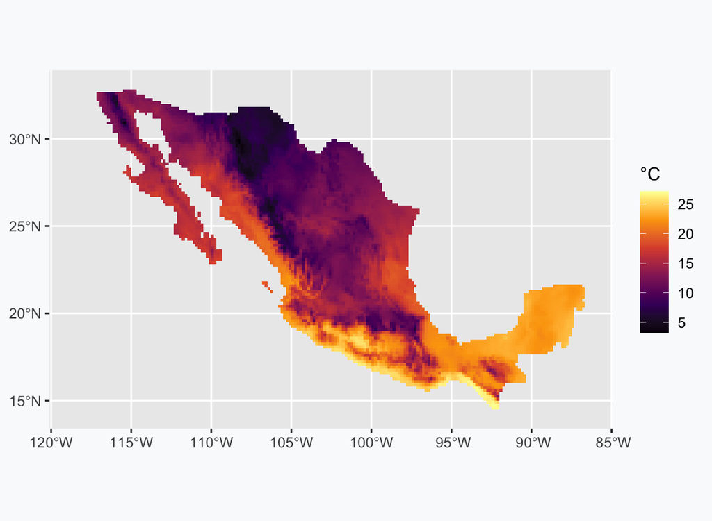

```r
ggplot() +
  geom_spatraster(data = tavg[["Jan"]]) +
  scale_fill_viridis_c(
    option = "inferno",
    na.value = NA,
    name = "°C")
```

`geom_spatraster()` is the raster equivalent of `geom_sf()`. Everything you know about scales and themes still applies.

## The Same Layer as `sf` Polygons

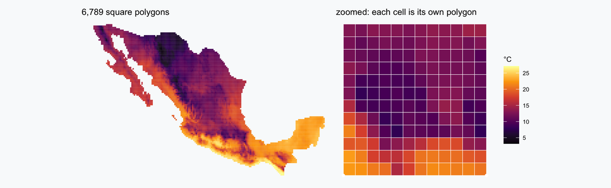

```r
#Step1: turn every cell into its own square polygon
jan_sf <- st_as_sf(as.polygons(tavg[["Jan"]], dissolve = FALSE, na.rm = TRUE))

ggplot(jan_sf) + geom_sf(aes(fill = Jan), colour = NA)
```

The same map — now as **6,789 POLYGON features**, each storing its own five corner coordinates. The values take **168 KB**; the polygons take **5,150 KB**, about **30 times more**, to say exactly what extent and resolution already said.

## All Twelve Months

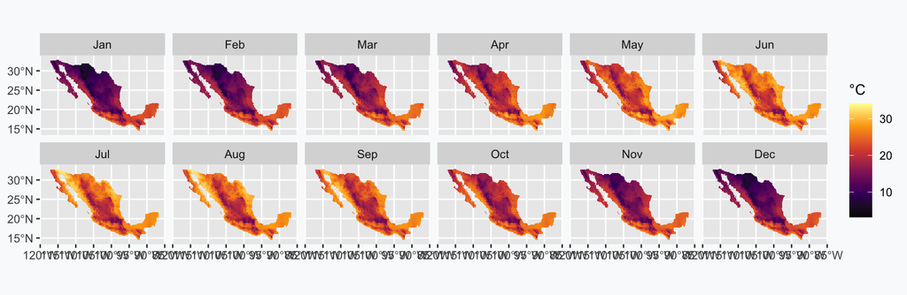

```r
ggplot() +
  geom_spatraster(data = tavg) +
  facet_wrap(~lyr, ncol = 6) +
  scale_fill_viridis_c(option = "inferno", na.value = NA, name = "°C")
```

One `facet_wrap` over twelve layers. The north swings hard between winter and summer; the Yucatán barely moves.

# Part C: Raster Algebra

## Arithmetic Just Works

Rasters on the same grid can be added, subtracted, multiplied, compared — **cell by cell**.

```r
#Step1: The annual mean across the 12 monthly layers
annual_temp <- mean(tavg)
names(annual_temp) <- "tavg"

#Step2: Seasonal range -- how much the year swings
temp_range <- max(tavg) - min(tavg)
names(temp_range) <- "temp_range"

#minmax() reads the range straight off the layer
round(minmax(annual_temp), 1)
```

```
    tavg
min  8.0
max 28.2
```

**8.0 °C to 28.2 °C** across the country.

## Two Derived Surfaces

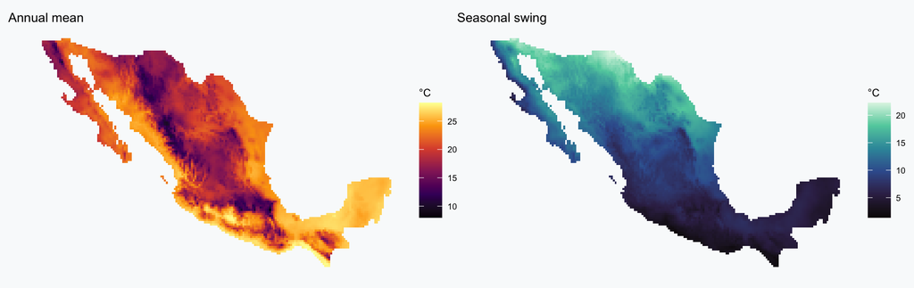

```r
map_annual_temp <- ggplot() + geom_spatraster(data = annual_temp) +
  scale_fill_viridis_c(option = "inferno", na.value = NA) + ggtitle("Annual mean")
map_temp_range <- ggplot() + geom_spatraster(data = temp_range) +
  scale_fill_viridis_c(option = "mako", na.value = NA) + ggtitle("Seasonal swing")
map_annual_temp + map_temp_range
```

Two completely different maps from the same twelve layers.

## Logical Operations Give You Masks

```r
#Step1: A comparison returns TRUE/FALSE per cell
is_hot <- annual_temp > 25
```

1,130 of 6,789 land cells average above 25 °C — about **17% of the country**.

**Warning**

Cell *counts* are not **area** unless every cell is the same size. In EPSG:4326 they are not — a degree of longitude shrinks toward the poles. Project first if you need real areas.

## The Mask, Mapped

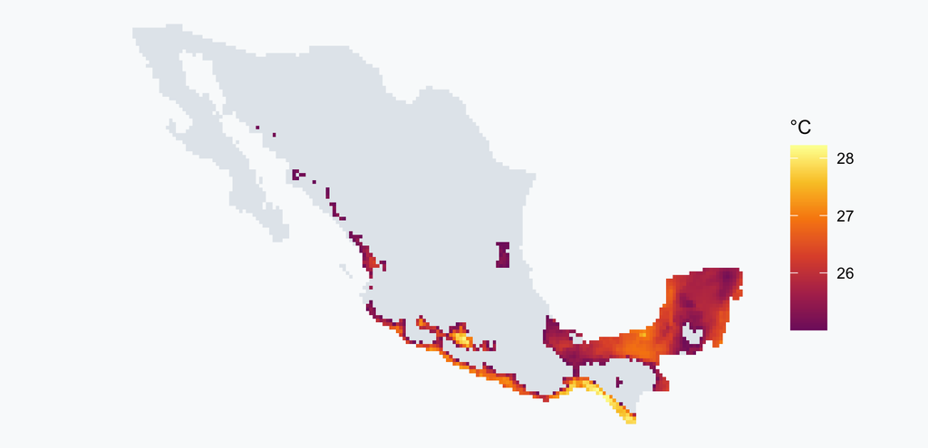

```r
#Step1: filter() keeps the matching cells, turns the rest into NA
hot_only <- annual_temp %>%
  filter(tavg > 25)              # = mask(annual_temp, is_hot, ...)

ggplot() + geom_spatraster(data = hot_only) +
  scale_fill_viridis_c(option = "inferno", na.value = NA)
```

`filter()` masks by **values**; masking by a **shape** still needs `mask()`.

## Your Turn: Where Does July Pass 32 °C?

**Build the mask, count the cells, then map them.** Which part of the country survives?

```r
#Step1: the mask
scorching <- tavg[["Jul"]] > 32

#Step2: count the cells before you draw anything
sum(values(scorching), na.rm = TRUE)

#Step3: keep only those cells, then map as before
hot_july <- tavg[["Jul"]] %>%
  filter(Jul > 32)
```

Guess the number first. There are **6,789** land cells in total.

## Coarsening: `aggregate`

```r
#Step1: where we start -- 0.17 degrees, 21,504 cells
ncell(annual_temp)
```

```
[1] 21504
```

```r
round(res(annual_temp)[1], 3)
```

```
[1] 0.167
```

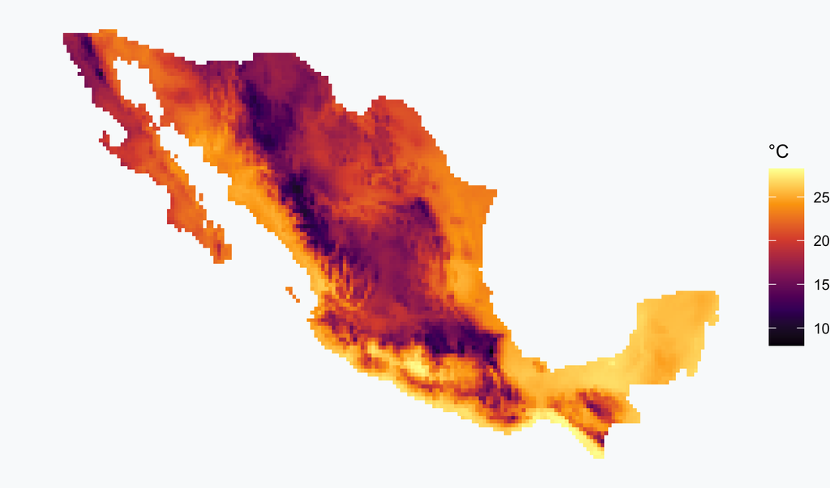

## Coarsening: `aggregate`

```r
#Step2: blocks of 3x3 cells, each replaced by their mean
coarse <- aggregate(annual_temp, fact = 3, fun = mean)
ncell(coarse)
```

```
[1] 2432
```

```r
round(res(coarse)[1], 3)
```

```
[1] 0.5
```

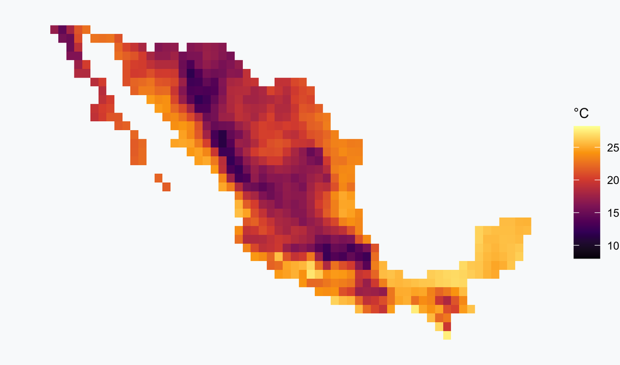

## Coarsening: `aggregate`

```r
#Step3: push it to 9x9
coarser <- aggregate(annual_temp, fact = 9, fun = mean)
ncell(coarser)
```

```
[1] 286
```

```r
round(res(coarser)[1], 3)
```

```
[1] 1.5
```

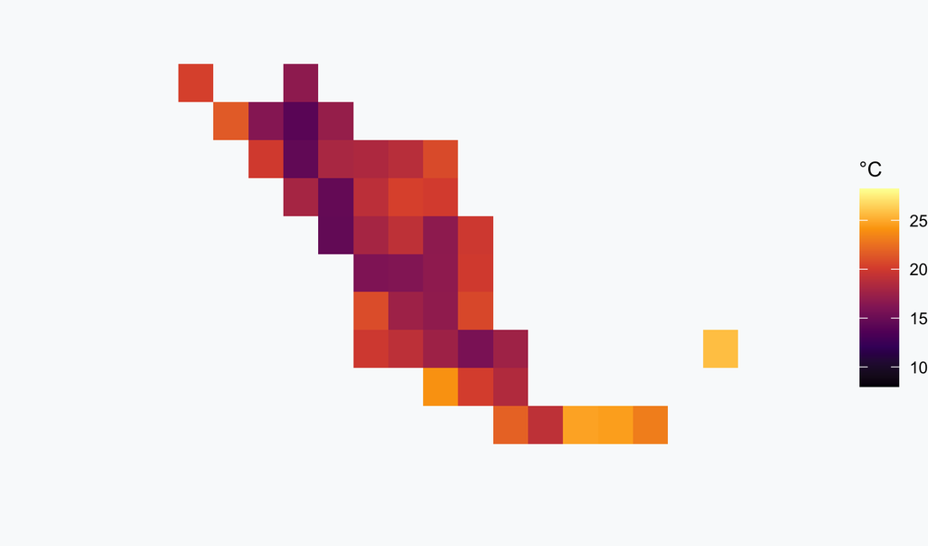

## Reprojecting a Raster

```r
projected <- project(annual_temp, "EPSG:6372")
round(res(projected))
```

```
[1] 17254 17254
```

Now each cell is about **17 km × 17 km** in real metres.

**Important**

Reprojecting a **vector** moves exact coordinates. Reprojecting a **raster** must build a new grid and **interpolate** values into it — so it changes your data. Reproject once, as late as possible, and use `method = "near"` for categorical rasters like land cover.

# Part D: Rasters Meet Vectors

## Crop and Mask

Two operations that sound alike and are not:

- **`crop`** cuts the raster down to a **rectangle** — the bounding box of your vector
- **`mask`** sets cells **outside the actual shape** to `NA`

```r
states <- st_read("../data/gadm41_MEX_shp/gadm41_MEX_1.shp", quiet = TRUE) %>%
  st_transform(4326) %>%
  rename(state_name = NAME_1)
yuc <- states %>%
  filter(state_name == "Yucatán")

cropped <- crop(annual_temp, vect(yuc))     # rectangle
masked  <- mask(cropped, vect(yuc))    # shape
```

You almost always want **crop then mask**, in that order — cropping first makes the mask far cheaper.

## The Difference, Drawn

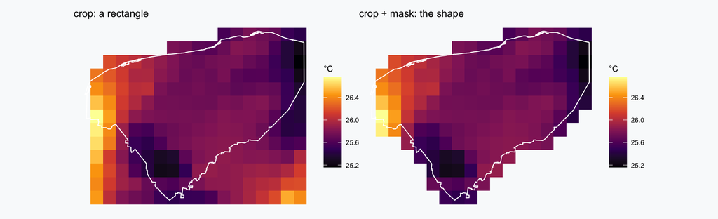

## `extract`: The Operation That Matters

This is why rasters are worth learning. **`extract` turns a surface into a column in your table.**

```r
#Step1: One value per polygon -- the mean of all cells inside it
tavg_by_state <- terra::extract(annual_temp, vect(states), fun = mean, na.rm = TRUE)
head(tavg_by_state, 3)
```

```
  ID     tavg
1  1 16.69675
2  2 18.36143
3  3 21.49858
```

```r
#Step2: Attach it to the sf object
states$tavg <- tavg_by_state$tavg
```

## What `extract` Did

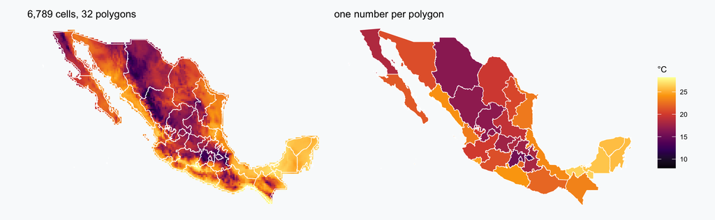

Every cell inside a boundary collapses to its **mean**. On the same colour scale you can see the cost: the surface ran **8.0 to 28.2 °C**, the 32 state means only **13.4 to 26.5 °C**. Averaging eats both tails.

## Hottest States

```r
states %>%
  st_drop_geometry() %>%
  arrange(desc(tavg)) %>%
  transmute(state_name, tavg = round(tavg, 1)) %>%
  head(4)
```

```
    state_name tavg
1      Tabasco 26.5
2     Campeche 26.0
3      Yucatán 25.8
4 Quintana Roo 25.7
```

Tabasco at 26.5 °C — and the next three are its neighbours. The whole **southeastern lowland**, none of it far above sea level.

## All Thirty-Two, Ranked

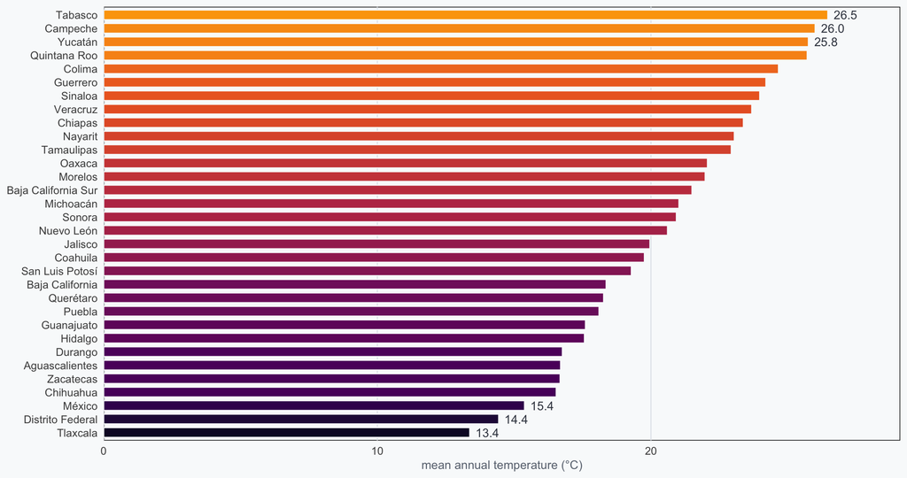

## A Choropleth of Extracted Values

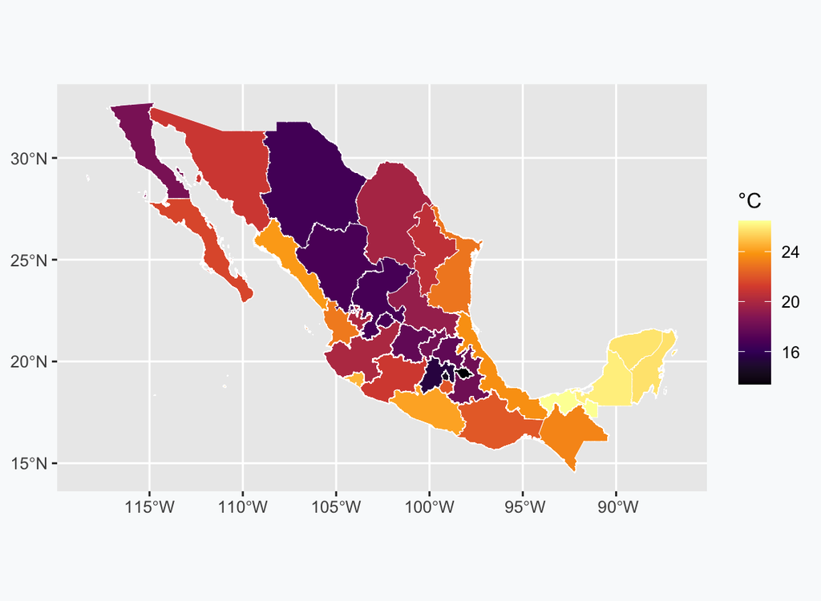

```r
ggplot(states) +
  geom_sf(aes(fill = tavg),
          colour = "white",
          linewidth = 0.15) +
  scale_fill_viridis_c(option = "inferno",
                       name = "°C")
```

We are back in **Session 3**. Once extracted, a raster variable is just another column to map, classify, and join.

## Cells Do Not Respect Borders

An 18 km cell straddling a state line belongs partly to each. `terra::extract` includes a cell if its **centre** falls inside.

`exactextractr` weights each cell by the **fraction** of it that the polygon covers:

```r
states$tavg_exact <- exact_extract(annual_temp, states, "mean", progress = FALSE)

round(max(abs(states$tavg - states$tavg_exact), na.rm = TRUE), 3)
```

```
[1] 0.165
```

A maximum difference of **0.165 °C** here — small, because our states are far larger than the cells. For **municipios** at this resolution the difference would be serious.

**Tip**

Rule of thumb: if your polygons are not many times bigger than your cells, use `exactextractr`.

## The Two Rules, Drawn

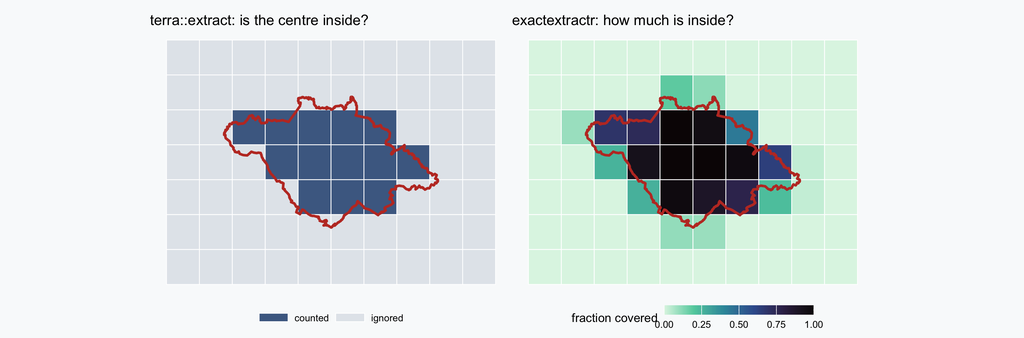

## The Same Polygon, Two Answers

```r
terra::extract(annual_temp, vect(tlax), fun = mean, na.rm = TRUE)$tavg
exact_extract(annual_temp, tlax, "mean")
```

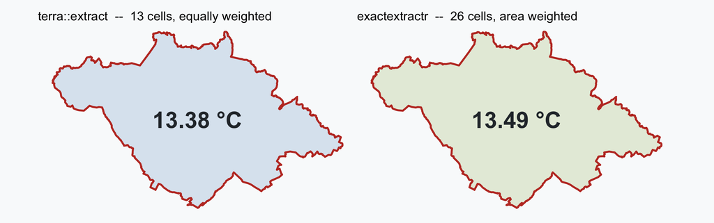

Same polygon, same raster, two defensible numbers **0.12 °C** apart. Nothing is broken — the two functions were asked slightly different questions, and the smaller the polygon gets relative to the cell, the further apart their answers drift.

# Part E: Wrapping Up

## Where to Get Rasters

| Source | What | Resolution |
| --- | --- | --- |
| **WorldClim** | climate normals | 1 km – 20 km |
| **WorldPop** | population counts | 100 m – 1 km |
| **SRTM / Copernicus DEM** | elevation | 30 m |
| **VIIRS night lights** | economic activity proxy | 500 m |
| **INEGI / CONABIO** | land use, vegetation | varies |

For the reto, **WorldPop** is the one to reach for — it gives you the population denominator we kept wishing for in Session 3.

## What Have We Learned?

That is the course. You can now read, join, measure, classify, map, and extract — which is most of applied spatial analysis.

# Teaching Evaluation

[figure not shown]

forms.gle/3VzPTovn8FxbWSUG9